# Beer Recommendation Tests

Chris Ballenger, Selwyn Samuel, and Bhuvana Adur Kannan

8/13/2018

### Question

**When a beer enthusiast/connoisseur walks into a brewery can we recommend a beer that he/she would like based on their past ratings profile?**

#### Data Gathering

We used web scraping techniques using rvest R Package and RSelenium server to collect data from untappd.com to answer this question. The steps we took to collect the data are shown in the diagram below:

[figure not shown]

WebScraping Steps

The R code that we used to do the scraping are given below.

```r
library(RCurl)
library(XML)
library(ggplot2)
library(httr)
library(rvest)
library(kableExtra)
library(tidyr)
library(RSelenium)
library(stringr)

setwd('C:/SMU/Courses/MSDS 6306 - DoingDataScience/github/MSDS_CaseStudy2/')
source("env.R")
source("Untappd_functions.R")

#
#
#
get_user_checkin_nodes <- function(user.url, remDr, user.name) {
  remDr$navigate(user.url)
  window.handle <- remDr$getCurrentWindowHandle()
  #
  # - Used Microsoft Edge with Developer Tools option to get to the right button to click
  # - Saved html file as XML and formatted it for easy readability
  #
  user.page <- read_html(as.character(remDr$getPageSource()))
  user.activity <- html_nodes(user.page, 'div[class="activity box"]')
  user.page.selector <- paste('div a[href="/user/', user.name, '"] span[class="stat"]', sep = "")
  #user.checkin.total <- html_nodes(user.page, 'div a[href="/user/Chrisballenger"] span[class="stat"]')
  user.checkin.total <- html_nodes(user.page, user.page.selector)
  user.checkin.total <- as.numeric(html_text(user.checkin.total))

  banner.frame <- remDr$switchToFrame("branch-banner-iframe")
  banner.button <- remDr$findElement(using = "css selector", "#branch-banner-close")
  banner.button$clickElement()

  remDr$navigate(user.url)
  load.button.selector <- paste('a[data-user-name="', user.name, '"]', sep = "")
  load.button <- remDr$findElement(using = "css selector", load.button.selector)

  # there are 15 checkins per scroll
  loop.count <- round(user.checkin.total / 15)

  for(counter in 1:13) {
    print(counter)
    load.button$clickElement()
    Sys.sleep(5)
  }

  user.page <- read_html(as.character(remDr$getPageSource()))
  user.activity <- html_nodes(user.page, 'div[class="activity box"]')
  user.checkins.nodes <- user.activity %>% html_nodes('div .item')
}

#
# Given a user name, the function will return a data frame of all the user checkin details
#
get_user_checkins <- function(user.name) {

  user.checkins <- data.frame(matrix(ncol = 47, nrow = 0))
  colnames(user.checkins) <- c("UserName", "UserId", "CheckinId", "BeerId", "BeerName", "LocationId", "LocationName", "BreweryId", "BeerRating", "ABV", "IBU", "Style",
                               "Light", "Smooth", "Clean", "Sweet", "Woody", "Zippy", "Strong", "Hoppy", "Floral", "Citrus", "Milk", "Dark", "Creamy", "Mouthfeel",
                               "Soft", "Boozy", "Caramel", "Oatmeal", "Dry", "Malty", "Piney", "Grassy", "Tart", "Sour", "Salty", "Fruity", "Heat", "Bitter", "Coffee",
                               "Roasty", "Chocolate", "Juicy", "Funky", "Acidic", "Crushable")

  remDr <- get_remote_chrome_driver()
  user.url <- paste(base.url, "user/", user.name, sep = "")

  user.checkins.nodes <- get_user_checkin_nodes(user.url, remDr, user.name)
  message("Number of checkin Nodes: ", length(user.checkins.nodes))
  write(as.character(user.checkins.nodes), file="C:/SMU/Courses/MSDS 6306 - DoingDataScience/github/MSDS_CaseStudy2/data/ChrisCheckins1.xml")

  for(counter in 1:length(user.checkins.nodes)) {

    print(counter)
    tryCatch({
      current.node <- user.checkins.nodes[counter]
      CheckinId <- html_attr(current.node, "data-checkin-id")
      message("Processing checkin... ", CheckinId)
      newCheckIn <- data.frame(CheckinId=CheckinId, UserName=user.name, Light=0, Smooth=0, Clean=0, Sweet=0, Woody=0, Zippy=0, Strong=0, Hoppy=0, Floral=0, Citrus=0,
                               Milk=0, Dark=0, Creamy=0, Mouthfeel=0, Soft=0, Boozy=0, Caramel=0, Oatmeal=0, Dry=0, Malty=0, Piney=0, Grassy=0, Tart=0, Sour=0,
                               Salty=0, Fruity=0, Heat=0, Bitter=0, Coffee=0, Roasty=0, Chocolate=0, Juicy=0, Funky=0, Acidic=0, Crushable=0, LocationName="", LocationId=0)

      checkin.url <- paste(user.url, "/checkin/", CheckinId, sep = "")
      remDr$navigate(checkin.url)

      checkin.page <- read_html(as.character(remDr$getPageSource()))
      checkin.node <- html_nodes(checkin.page, 'div[class="checkin box"]')
      location.url <- html_attr(html_nodes(checkin.node, 'div p[class="location"] a'), "href")
      location.name <- html_text(html_nodes(checkin.node, 'div p[class="location"] a'))
      location.id <- tail(unlist(strsplit(location.url, "/")), n=1)
      if(length(location.id) > 0) { newCheckIn$LocationId <- location.id }
      if(length(location.name) > 0) { newCheckIn$LocationName <- location.name }

      beer.url <- html_attr(html_nodes(checkin.node, 'div[class="beer"] p a'), "href")
      beer.name <- html_text(html_nodes(checkin.node, 'div [class="beer"] p a'))
      beer.id <- tail(unlist(strsplit(beer.url, "/")), n=1)
      beer.rating.nodes <- html_nodes(checkin.node, 'div[class="rating-serving"] span')
      if(length(beer.rating.nodes) > 1) {
        beer.rating.str <- html_attr(html_nodes(checkin.node, 'div[class="rating-serving"] span')[2], "class")
      } else {
        beer.rating.str <- html_attr(html_nodes(checkin.node, 'div[class="rating-serving"] span')[1], "class")
      }
      beer.rating <- substring(beer.rating.str, nchar(beer.rating.str)-2)
      newCheckIn$BeerId <- beer.id
      newCheckIn$BeerName <- beer.name
      newCheckIn$BeerRating <- as.numeric(beer.rating)/100

      flavors.list <- html_text(html_nodes(checkin.node, 'div[class="flavor"] ul li span'))
      #print(flavors.list)
      if(length(flavors.list) > 0) {
        if("Light" %in% flavors.list) { newCheckIn$Light = 1 }
        if("Smooth" %in% flavors.list) { newCheckIn$Smooth = 1 }
        if("Clean" %in% flavors.list) { newCheckIn$Clean = 1 }
        if("Sweet" %in% flavors.list) { newCheckIn$Sweet = 1 }
        if("Woody" %in% flavors.list) { newCheckIn$Woody = 1 }
        if("Zippy" %in% flavors.list) { newCheckIn$Zippy = 1 }
        if("Strong" %in% flavors.list) { newCheckIn$Strong = 1 }
        if("Hoppy" %in% flavors.list) { newCheckIn$Hoppy = 1 }
        if("Floral" %in% flavors.list) { newCheckIn$Floral = 1 }
        if("Citrus" %in% flavors.list) { newCheckIn$Citrus = 1 }
        if("Milk" %in% flavors.list) { newCheckIn$Milk = 1 }
        if("Dark" %in% flavors.list) { newCheckIn$Dark = 1 }
        if("Creamy" %in% flavors.list) { newCheckIn$Creamy = 1 }
        if("Mouthfeel" %in% flavors.list) { newCheckIn$Mouthfeel = 1 }
        if("Soft" %in% flavors.list) { newCheckIn$Soft = 1 }
        if("Boozy" %in% flavors.list) { newCheckIn$Boozy = 1 }
        if("Caramel" %in% flavors.list) { newCheckIn$Caramel = 1 }
        if("Oatmeal" %in% flavors.list) { newCheckIn$Oatmeal = 1 }
        if("Dry" %in% flavors.list) { newCheckIn$Dry = 1 }
        if("Malty" %in% flavors.list) { newCheckIn$Malty = 1 }
        if("Piney" %in% flavors.list) { newCheckIn$Piney = 1 }
        if("Grassy" %in% flavors.list) { newCheckIn$Grassy = 1 }
        if("Tart" %in% flavors.list) { newCheckIn$Tart = 1 }
        if("Sour" %in% flavors.list) { newCheckIn$Sour = 1 }
        if("Salty" %in% flavors.list) { newCheckIn$Salty = 1 }
        if("Fruity" %in% flavors.list) { newCheckIn$Fruity = 1 }
        if("Heat" %in% flavors.list) { newCheckIn$Heat = 1 }
        if("Bitter" %in% flavors.list) { newCheckIn$Bitter = 1 }
        if("Coffee" %in% flavors.list) { newCheckIn$Coffee = 1 }
        if("Roasty" %in% flavors.list) { newCheckIn$Roasty = 1 }
        if("Chocolate" %in% flavors.list) { newCheckIn$Chocolate = 1 }
        if("Juicy" %in% flavors.list) { newCheckIn$Juicy = 1 }
        if("Funky" %in% flavors.list) { newCheckIn$Funky = 1 }
        if("Acidic" %in% flavors.list) { newCheckIn$Acidic = 1 }
        if("Crushable" %in% flavors.list) { newCheckIn$Crushable = 1 }
      }
```

```r
      print(newCheckIn)
      user.checkins <- rbind(user.checkins, newCheckIn)
      Sys.sleep(5)
    },
      error=function(e) {
      message("Error in: ", checkin.url)
      message(e)
      counter <- counter + 1
    })
  }
  close_remote_chrome_driver(remDr)
  write.csv(user.checkins, file=paste("C:/SMU/Courses/MSDS 6306 - DoingDataScience/github/MSDS_CaseStudy2/data/", user.name, "Profile.csv", sep = ""), row.names = FALSE)
  user.checkins
}

#
# Given a user name, the function will return a data frame of all the user checkin details
#
get_beer_details <- function(file.name) {

  beer.details <- data.frame(matrix(ncol = 46, nrow = 0))
  colnames(beer.details) <- c("BeerId", "BreweryName", "BreweryURL", "Style", "ABV", "IBU", "BeerRating", "TotalRatings", "TotalCheckins", "UniqueCheckins",
                              "MonthlyCheckins", "Light", "Smooth", "Clean", "Sweet", "Woody", "Zippy", "Strong", "Hoppy", "Floral", "Citrus", "Milk", "Dark", "Creamy",
                              "Mouthfeel", "Soft", "Boozy", "Caramel", "Oatmeal", "Dry", "Malty", "Piney", "Grassy", "Tart", "Sour", "Salty", "Fruity", "Heat",
                              "Bitter", "Coffee", "Roasty", "Chocolate", "Juicy", "Funky", "Acidic", "Crushable")

  beer.ids <- read.csv(file.name)
  remDr <- get_remote_chrome_driver()

  #for(row in 1:nrow(beer.ids)) {
  for(row in 1:nrow(beer.ids)) {

    print(row)
    tryCatch({
      message("Processing Beer Id... ", beer.ids[row,]$BeerId)
      newBeer <- data.frame(BeerId=beer.ids[row,]$BeerId, BreweryName="", BreweryURL="", Style="", ABV="0%", IBU=0, BeerRating=0, TotalRatings=0, TotalCheckins=0, UniqueCheckins=0,
                            MonthlyCheckins=0, Light=0, Smooth=0, Clean=0, Sweet=0, Woody=0, Zippy=0, Strong=0, Hoppy=0, Floral=0, Citrus=0, Milk=0, Dark=0, Creamy=0, Mouthfeel=0,
                            Soft=0, Boozy=0, Caramel=0, Oatmeal=0, Dry=0, Malty=0, Piney=0, Grassy=0, Tart=0, Sour=0, Salty=0, Fruity=0, Heat=0, Bitter=0, Coffee=0, Roasty=0,
                            Chocolate=0, Juicy=0, Funky=0, Acidic=0, Crushable=0)

      beer.url <- paste(base.url, "beer/", beer.ids[row, "BeerId"], sep = "")
      remDr$navigate(beer.url)
      window.handle <- remDr$getCurrentWindowHandle()

      beer.page <- read_html(as.character(remDr$getPageSource()))
      beer.detail.node <- html_nodes(beer.page, 'div[class="box b_info"]')

      newBeer$BreweryName <- html_text(html_nodes(beer.detail.node, 'div[class="name"] p[class="brewery"] a'))
      newBeer$BreweryURL <- html_attr(html_nodes(beer.detail.node, 'div[class="name"] p[class="brewery"] a'), "href")
      newBeer$Style <- html_text(html_nodes(beer.detail.node, 'div[class="name"] p[class="style"]'))
      newBeer$ABV <- tail(unlist(strsplit(trimws(html_text(html_nodes(beer.detail.node, 'div[class="details"] p[class="abv"]'))), " ")), n=2)[1]
      newBeer$IBU <- tail(unlist(strsplit(trimws(html_text(html_nodes(beer.detail.node, 'div[class="details"] p[class="ibu"]'))), " ")), n=2)[1]
      newBeer$TotalRatings <- tail(unlist(strsplit(trimws(html_text(html_nodes(beer.detail.node, 'div[class="details"] p[class="raters"]'))), " ")), n=2)[1]
      beer.rating.str <- html_attr(html_nodes(beer.detail.node, 'div[class="details"] p[class="rating"] span'), "class")[1]
      newBeer$BeerRating <- as.numeric(substring(beer.rating.str, nchar(beer.rating.str)-2))/100

      counts.list <- html_text(html_nodes(beer.detail.node, 'div[class="stats"] p span[class="count"]'))
      newBeer$TotalCheckins <- counts.list[1]
      newBeer$UniqueCheckins <- counts.list[2]
      newBeer$MonthlyCheckins <- counts.list[3]

      beer.description <- strsplit(trimws(html_text(html_nodes(beer.detail.node, 'div[class="bottom"] div[class="desc"] div[class="beer-descrption-read-less"]'))), " ")
      if(length(beer.description) > 0) {
        if(str_detect(beer.description, fixed("Light", ignore_case=TRUE))) { newBeer$Light = 1 }
        if(str_detect(beer.description, fixed("Smooth", ignore_case=TRUE))) { newBeer$Smooth = 1 }
        if(str_detect(beer.description, fixed("Clean", ignore_case=TRUE))) { newBeer$Clean = 1 }
        if(str_detect(beer.description, fixed("Sweet", ignore_case=TRUE))) { newBeer$Sweet = 1 }
        if(str_detect(beer.description, fixed("Woody", ignore_case=TRUE))) { newBeer$Woody = 1 }
        if(str_detect(beer.description, fixed("Zippy", ignore_case=TRUE))) { newBeer$Zippy = 1 }
        if(str_detect(beer.description, fixed("Strong", ignore_case=TRUE))) { newBeer$Strong = 1 }
        if(str_detect(beer.description, fixed("Hoppy", ignore_case=TRUE))) { newBeer$Hoppy = 1 }
        if(str_detect(beer.description, fixed("Floral", ignore_case=TRUE))) { newBeer$Floral = 1 }
        if(str_detect(beer.description, fixed("Citrus", ignore_case=TRUE))) { newBeer$Citrus = 1 }
        if(str_detect(beer.description, fixed("Milk", ignore_case=TRUE))) { newBeer$Milk = 1 }
        if(str_detect(beer.description, fixed("Dark", ignore_case=TRUE))) { newBeer$Dark = 1 }
        if(str_detect(beer.description, fixed("Creamy", ignore_case=TRUE))) { newBeer$Creamy = 1 }
        if(str_detect(beer.description, fixed("Mouthfeel", ignore_case=TRUE))) { newBeer$Mouthfeel = 1 }
        if(str_detect(beer.description, fixed("Soft", ignore_case=TRUE))) { newBeer$Soft = 1 }
        if(str_detect(beer.description, fixed("Boozy", ignore_case=TRUE))) { newBeer$Boozy = 1 }
        if(str_detect(beer.description, fixed("Caramel", ignore_case=TRUE))) { newBeer$Caramel = 1 }
        if(str_detect(beer.description, fixed("Oatmeal", ignore_case=TRUE))) { newBeer$Oatmeal = 1 }
        if(str_detect(beer.description, fixed("Dry", ignore_case=TRUE))) { newBeer$Dry = 1 }
        if(str_detect(beer.description, fixed("Malty", ignore_case=TRUE))) { newBeer$Malty = 1 }
        if(str_detect(beer.description, fixed("Piney", ignore_case=TRUE))) { newBeer$Piney = 1 }
        if(str_detect(beer.description, fixed("Grassy", ignore_case=TRUE))) { newBeer$Grassy = 1 }
        if(str_detect(beer.description, fixed("Tart", ignore_case=TRUE))) { newBeer$Tart = 1 }
        if(str_detect(beer.description, fixed("Sour", ignore_case=TRUE))) { newBeer$Sour = 1 }
        if(str_detect(beer.description, fixed("Salty", ignore_case=TRUE))) { newBeer$Salty = 1 }
        if(str_detect(beer.description, fixed("Fruity", ignore_case=TRUE))) { newBeer$Fruity = 1 }
        if(str_detect(beer.description, fixed("Heat", ignore_case=TRUE))) { newBeer$Heat = 1 }
        if(str_detect(beer.description, fixed("Bitter", ignore_case=TRUE))) { newBeer$Bitter = 1 }
        if(str_detect(beer.description, fixed("Coffee", ignore_case=TRUE))) { newBeer$Coffee = 1 }
        if(str_detect(beer.description, fixed("Roasty", ignore_case=TRUE))) { newBeer$Roasty = 1 }
        if(str_detect(beer.description, fixed("Chocolate", ignore_case=TRUE))) { newBeer$Chocolate = 1 }
        if(str_detect(beer.description, fixed("Juicy", ignore_case=TRUE))) { newBeer$Juicy = 1 }
        if(str_detect(beer.description, fixed("Funky", ignore_case=TRUE))) { newBeer$Funky = 1 }
        if(str_detect(beer.description, fixed("Acidic", ignore_case=TRUE))) { newBeer$Acidic = 1 }
        if(str_detect(beer.description, fixed("Crushable", ignore_case=TRUE))) { newBeer$Crushable = 1 }
      }
      print(newBeer)
      beer.details <- rbind(beer.details, newBeer)
      Sys.sleep(5)
    },
    error=function(e) {
      message("Error in: ", beer.url)
      message(e)
      row <- row + 1
      Sys.sleep(5)
    })
  }
  close_remote_chrome_driver(remDr)
  write.csv(beer.details, file="C:/SMU/Courses/MSDS 6306 - DoingDataScience/github/MSDS_CaseStudy2/data/Chris-BeerDetails.csv", row.names = FALSE)
  beer.details
}
```

#### Feature Selection

[figure not shown]

Feature Selection

#### Random Forest Iterations and Recommenderlab algorithms and Results

We ran the Random Forest algorithm with 1555 observations and 40 features and the results are as follows:

[figure not shown]

Iteration 1

We modified the model to predict a yes or no instead of an Ordinal rating. The results are as follows:

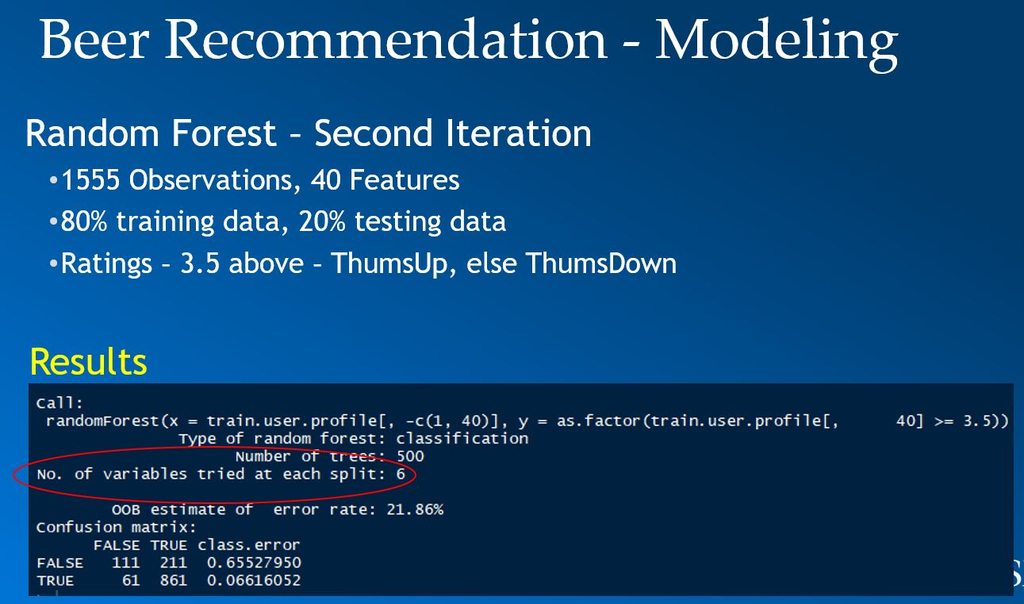

Iteration 2

We reduced the number of features to the top 5 most influential features and ran the model. The results are as follows:

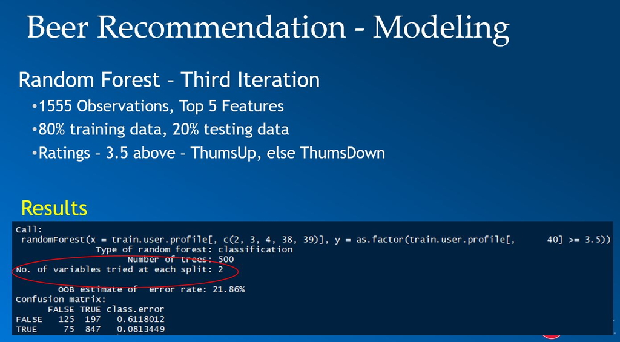

Iteration 3

We also ran some beer recommendation predictions using the R recommenderlab package and the results are as follows:

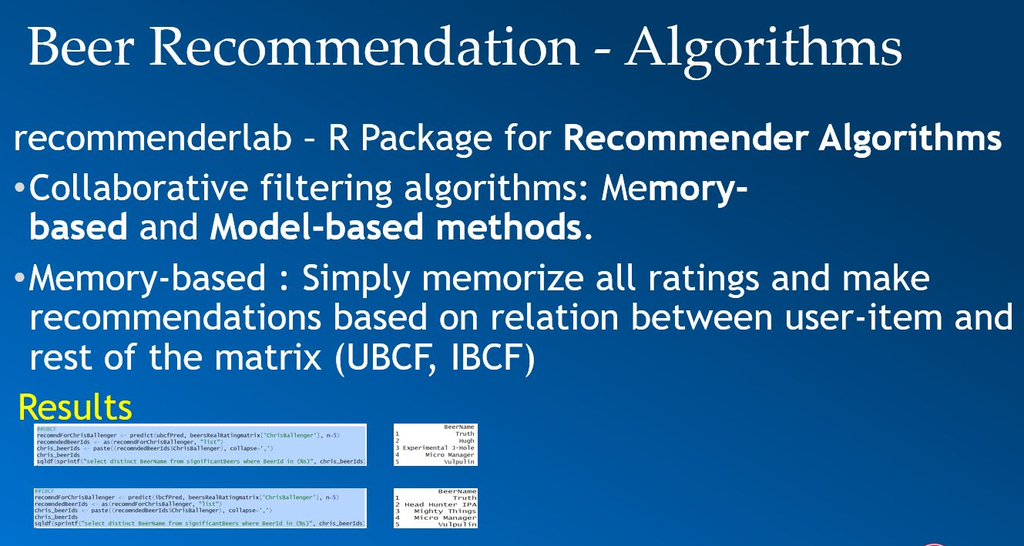

Recommenderlab

#### Conclusion

We observed the following using Random Forest:

- The percentage of variation in the rating explained by the variation of the features was only 52.32% which is rather low.
- The algorithm performed much better predicting the positive likes (94%) compared to the dislikes (35%).

We learnt a lot in going through the life cycle of a data science project including identifying the problem, gathering the data, selecting the features and fitting the models. Our lack of experience in using the algorithms prevented us from fine tuning the model. We need to learn more about Random Forest and other algorithms and their application in predictions like the beer peference in our case study.